# ECON 4370/6370 — Homework 2

**Jovanni Reyes (SMU ID: 49750812)**

Results computed from the supplied CPS and Welch-Goyal data files.

## 1. Return to Education for Subgroups

### Mincer Regression Results

| subgroup | alpha | beta_edu | beta_exp | beta_exp2 | se_edu | r_squared | n_obs |
| --- | --- | --- | --- | --- | --- | --- | --- |
| Male, High School or Less | 1.3264 | 0.0776 | 0.0401 | -0.0006 | 0.0031 | 0.1215 | 10856 |
| Male, College+ | 0.8997 | 0.1171 | 0.0489 | -0.0009 | 0.0022 | 0.1860 | 18131 |
| Female, High School or Less | 1.2470 | 0.0731 | 0.0284 | -0.0004 | 0.0039 | 0.0921 | 6752 |
| Female, College+ | 0.8472 | 0.1157 | 0.0301 | -0.0005 | 0.0022 | 0.1854 | 14806 |

### Visualizations

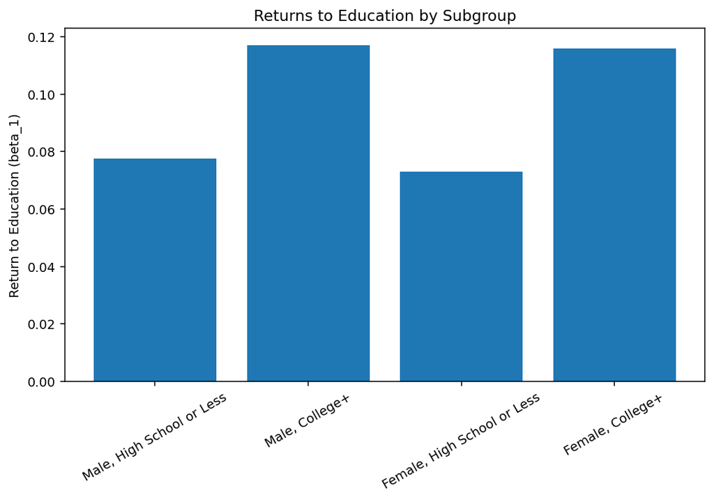

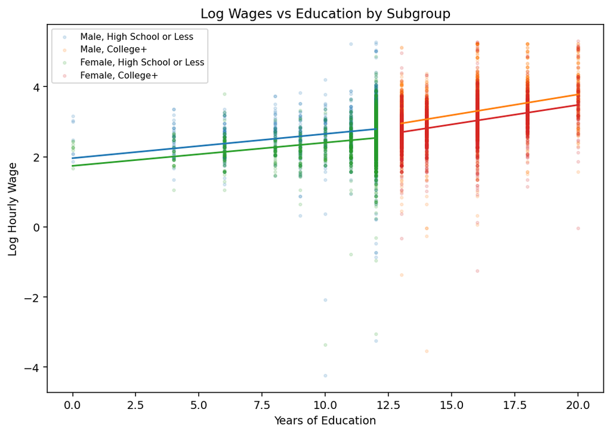

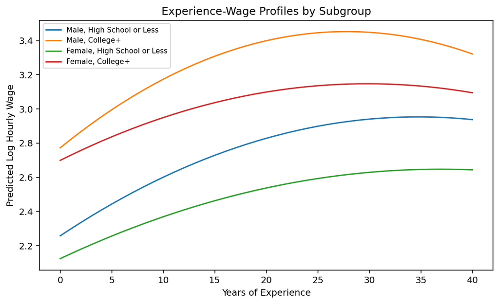

### Interpretation

The estimates show positive returns to education for all four subgroups. The education coefficient is about 0.0776 for men with high school or less, 0.1171 for men with College+, 0.0731 for women with high school or less, and 0.1157 for women with College+. Since the dependent variable is log hourly wage, an additional year of schooling is associated with a larger percentage increase in hourly wages for the College+ groups.

The experience coefficient is positive and squared experience is negative in every subgroup, producing the standard concave Mincer profile. The model explains more wage variation in the College+ groups (R-squared about 0.185–0.186) than in the High School or Less groups (about 0.092–0.121).

## 2. Rolling Window Estimation of the AR(1) Model

### First Six Rolling Estimates

| date | alpha | rho | se_alpha | se_rho | r_squared |
| --- | --- | --- | --- | --- | --- |
| 1937-01 | -0.0010 | 0.4125 | 0.0007 | 0.0838 | 0.1704 |
| 1937-02 | -0.0010 | 0.4099 | 0.0007 | 0.0839 | 0.1683 |
| 1937-03 | -0.0009 | 0.4105 | 0.0007 | 0.0844 | 0.1671 |
| 1937-04 | -0.0009 | 0.4187 | 0.0007 | 0.0841 | 0.1735 |
| 1937-05 | -0.0009 | 0.4233 | 0.0007 | 0.0835 | 0.1787 |
| 1937-06 | -0.0010 | 0.4105 | 0.0006 | 0.0827 | 0.1726 |

### Last Six Rolling Estimates

| date | alpha | rho | se_alpha | se_rho | r_squared |
| --- | --- | --- | --- | --- | --- |
| 2018-07 | 0.0005 | 0.5199 | 0.0003 | 0.0782 | 0.2727 |
| 2018-08 | 0.0006 | 0.5371 | 0.0003 | 0.0768 | 0.2929 |
| 2018-09 | 0.0006 | 0.5376 | 0.0003 | 0.0774 | 0.2901 |
| 2018-10 | 0.0007 | 0.5225 | 0.0003 | 0.0743 | 0.2953 |
| 2018-11 | 0.0009 | 0.4153 | 0.0003 | 0.0697 | 0.2312 |
| 2018-12 | 0.0010 | 0.3687 | 0.0003 | 0.0804 | 0.1511 |

### Rolling Persistence

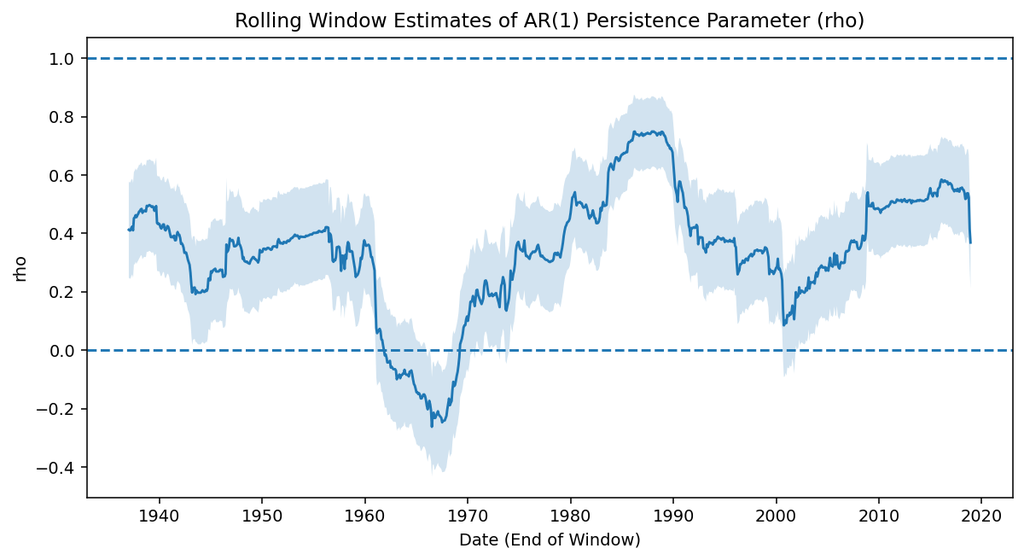

### What do you observe?

Inflation persistence is time-varying rather than constant. The estimated rho changes substantially across 10-year windows. Values closer to one imply more persistent shocks, while values closer to zero imply faster dissipation. By December 2018, rho is approximately **0.369**, after being above 0.5 earlier in 2018. Overall, the rolling estimates indicate meaningful variation in inflation persistence over the sample.